# bank

Daina Simo

2022-09-01

## Introduction

### Description du jeu de donnees

Ce jeu de donnees contient les informations sur environ 5000 client de banque et ce concentre sur la question de savoir quelles sont les caracteristiques qui determinent si un client souscrira a un depot a terme(compte epargne ou les interet produites sont eleves a condition que le client laisse le compte bloque pendant un nombre de temps) ou pas

## preparation des donnees

### Importation et premieres observation generale

1.Importation du jeu de donnees dans un dataframe et visualisation des premieres observations

```r
  data=read.csv('C:/Users/PC/Documents/R/bank.csv',sep=';')
   head(data)
```

```
##   age         job marital education default balance housing loan  contact day
## 1  30  unemployed married   primary      no    1787      no   no cellular  19
## 2  33    services married secondary      no    4789     yes  yes cellular  11
## 3  35  management  single  tertiary      no    1350     yes   no cellular  16
## 4  30  management married  tertiary      no    1476     yes  yes  unknown   3
## 5  59 blue-collar married secondary      no       0     yes   no  unknown   5
## 6  35  management  single  tertiary      no     747      no   no cellular  23
##   month duration campaign pdays previous poutcome  y
## 1   oct       79        1    -1        0  unknown no
## 2   may      220        1   339        4  failure no
## 3   apr      185        1   330        1  failure no
## 4   jun      199        4    -1        0  unknown no
## 5   may      226        1    -1        0  unknown no
## 6   feb      141        2   176        3  failure no
```

2.Informations sur le dataframe

```r
     dim(data)
```

```
## [1] 4521   17
```

```r
  summary(data)
```

```
##       age            job              marital           education
##  Min.   :19.00   Length:4521        Length:4521        Length:4521
##  1st Qu.:33.00   Class :character   Class :character   Class :character
##  Median :39.00   Mode  :character   Mode  :character   Mode  :character
##  Mean   :41.17
##  3rd Qu.:49.00
##  Max.   :87.00
##    default             balance        housing              loan
##  Length:4521        Min.   :-3313   Length:4521        Length:4521
##  Class :character   1st Qu.:   69   Class :character   Class :character
##  Mode  :character   Median :  444   Mode  :character   Mode  :character
##                     Mean   : 1423
##                     3rd Qu.: 1480
##                     Max.   :71188
##    contact               day           month              duration
##  Length:4521        Min.   : 1.00   Length:4521        Min.   :   4
##  Class :character   1st Qu.: 9.00   Class :character   1st Qu.: 104
##  Mode  :character   Median :16.00   Mode  :character   Median : 185
##                     Mean   :15.92                      Mean   : 264
##                     3rd Qu.:21.00                      3rd Qu.: 329
##                     Max.   :31.00                      Max.   :3025
##     campaign          pdays           previous         poutcome
##  Min.   : 1.000   Min.   : -1.00   Min.   : 0.0000   Length:4521
##  1st Qu.: 1.000   1st Qu.: -1.00   1st Qu.: 0.0000   Class :character
##  Median : 2.000   Median : -1.00   Median : 0.0000   Mode  :character
##  Mean   : 2.794   Mean   : 39.77   Mean   : 0.5426
##  3rd Qu.: 3.000   3rd Qu.: -1.00   3rd Qu.: 0.0000
##  Max.   :50.000   Max.   :871.00   Max.   :25.0000
##       y
##  Length:4521
##  Class :character
##  Mode  :character
##
##
##
```

3.Verification des doublons et valeurs manquantes

```r
 sum(is.na(data))
```

```
## [1] 0
```

```r
 anyDuplicated(data)
```

```
## [1] 0
```

4.Remarque Notre dataframe comporte 4521 lignes et 17 variables ou colones.

Nous n’avons pas de données manquantes car pour chaque ligne du dataframe toutes les informations sont renseignées.

### Nettoyage de donnees

```r
data_wrangling <- function(filepath,sep){

  df = read.csv(filepath,sep=sep)
  # Drop columns : `PatientID` and `AppointmentID`
  df = subset(df,select=colnames(df)[-c(12)])

  return (df)
}
```

```r
  data=data_wrangling('C:/Users/PC/Documents/R/bank.csv',';')
  head(data)
```

```
##   age         job marital education default balance housing loan  contact day
## 1  30  unemployed married   primary      no    1787      no   no cellular  19
## 2  33    services married secondary      no    4789     yes  yes cellular  11
## 3  35  management  single  tertiary      no    1350     yes   no cellular  16
## 4  30  management married  tertiary      no    1476     yes  yes  unknown   3
## 5  59 blue-collar married secondary      no       0     yes   no  unknown   5
## 6  35  management  single  tertiary      no     747      no   no cellular  23
##   month campaign pdays previous poutcome  y
## 1   oct        1    -1        0  unknown no
## 2   may        1   339        4  failure no
## 3   apr        1   330        1  failure no
## 4   jun        4    -1        0  unknown no
## 5   may        1    -1        0  unknown no
## 6   feb        2   176        3  failure no
```

## Analyse exploratoire

### Quelle est la proportion de client n’ayant pas souscrit a un depot a terme

```r
  count.y <- table(data$y)
prop.table(count.y)
```

```
##
##      no     yes
## 0.88476 0.11524
```

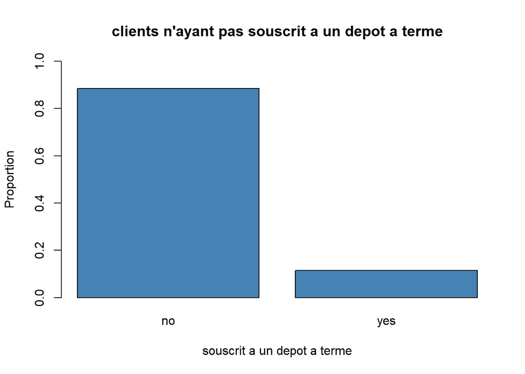

```r
barplot(prop.table(count.y),ylim = c(0,1),col="steelblue",main="clients n'ayant pas souscrit a un depot a terme",ylab="Proportion", xlab="souscrit a un depot a terme")
```

on constates que la proportion de clients n’ayant pas souscrit a un depot a terme est tres elevee 88,47%

### Y’ a t-il de forte chance qu’un client n’ayant pas souscrit l’annee precedente le refasse l’annee suivante?

```r
 count.poutcome=table(data$poutcome)
prop.table(count.poutcome)
```

```
##
##    failure      other    success    unknown
## 0.10838310 0.04357443 0.02853351 0.81950896
```

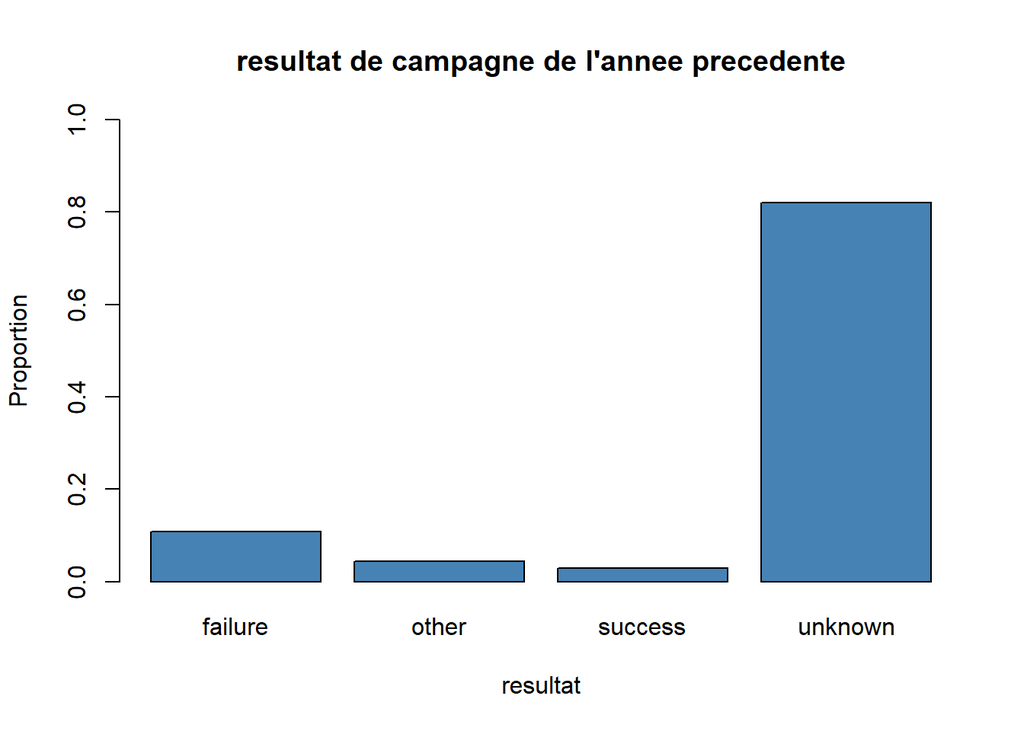

```r
 barplot(prop.table(count.poutcome),ylim = c(0,1),col="steelblue",main="resultat de campagne de l'annee precedente",ylab="Proportion", xlab="resultat")
```

```r
table(data$poutcome, data$y)
```

```
##
##             no  yes
##   failure  427   63
##   other    159   38
##   success   46   83
##   unknown 3368  337
```

```r
prop.table(table(data$poutcome, data$y))
```

```
##
##                   no        yes
##   failure 0.09444813 0.01393497
##   other   0.03516921 0.00840522
##   success 0.01017474 0.01835877
##   unknown 0.74496793 0.07454103
```

```r
prop.table(table(data$poutcome, data$y),1)
```

```
##
##                   no        yes
##   failure 0.87142857 0.12857143
##   other   0.80710660 0.19289340
##   success 0.35658915 0.64341085
##   unknown 0.90904184 0.09095816
```

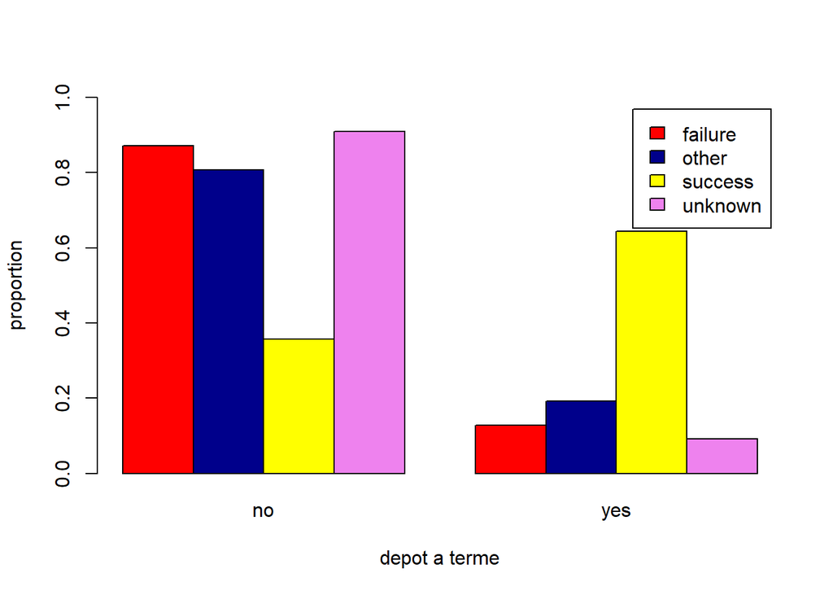

```r
agg <- prop.table(table(data$poutcome, data$y),1)
barplot(agg,
        xlab = "depot a terme", ylab = "proportion",
        col = c("red", "darkblue","yellow","violet"),
        legend.text = rownames(agg),
        beside = TRUE,
        ylim=c(0,1)) # Grou
```

```r
chisq.test(table(data$poutcome, data$y),correct = T)
```

```
##
##  Pearson's Chi-squared test
##
## data:  table(data$poutcome, data$y)
## X-squared = 386.88, df = 3, p-value < 2.2e-16
```

le test d’independance du khi deux au seuil 5%(p-valeur=0.0) est en faveur d’une association entre le statut d’un client l’annee precedente et le fait qu’il souscrira ou pas a un depot a terme.

### La campagne effectuée par la banque etait-elle forte(nombres de contacts effectues pendant la dite campagne)?

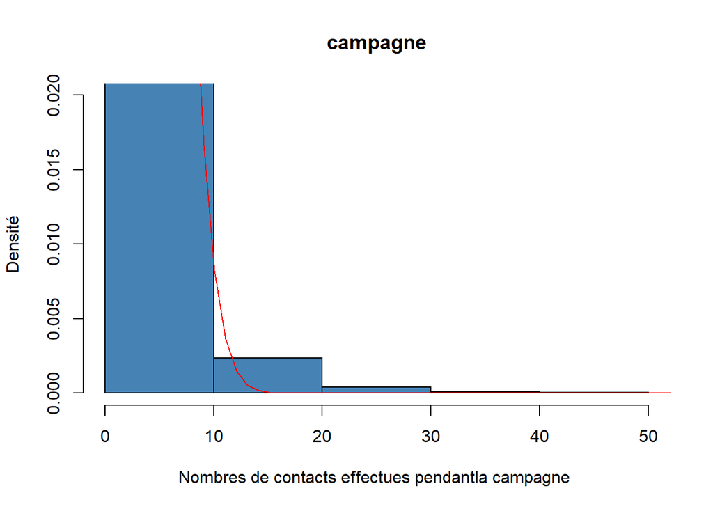

```r
 hist(data$campaign,
     breaks = 5,
     col="steelblue",
     main="campagne",
     xlab="Nombres de contacts effectues pendantla campagne ",
     ylab="Densité",
     freq=F,
     ylim=c(0,0.02))
x <- seq(0, 120, length.out=120)
y <- with(data, dnorm(x, mean(campaign), sd(campaign)))
lines(x, y, col = "red")
```

[figure not shown]

```r
boxplot(data$campaign,
        col="lightblue",
        horizontal = T,
        main="Boite à moustache de la distribution des âges",
        xlab="campagne"
        )
```

on constate que la majorite des clients ne sont pas assez conctater lors de la campagne .La majorite des client sont contactés moins de 4 fois(75%)

rare sont les clients qui sont contactés au-dela de 5 fois pendant la campagne.

### Quel est le statut matrimonial dominant?

```r
count.marital=table(data$marital)
prop.table(count.marital)
```

```
##
##  divorced   married    single
## 0.1167883 0.6186684 0.2645432
```

```r
prop.table(table(data$marital,data$y),1)
```

```
##
##                    no        yes
##   divorced 0.85416667 0.14583333
##   married  0.90096532 0.09903468
##   single   0.86036789 0.13963211
```

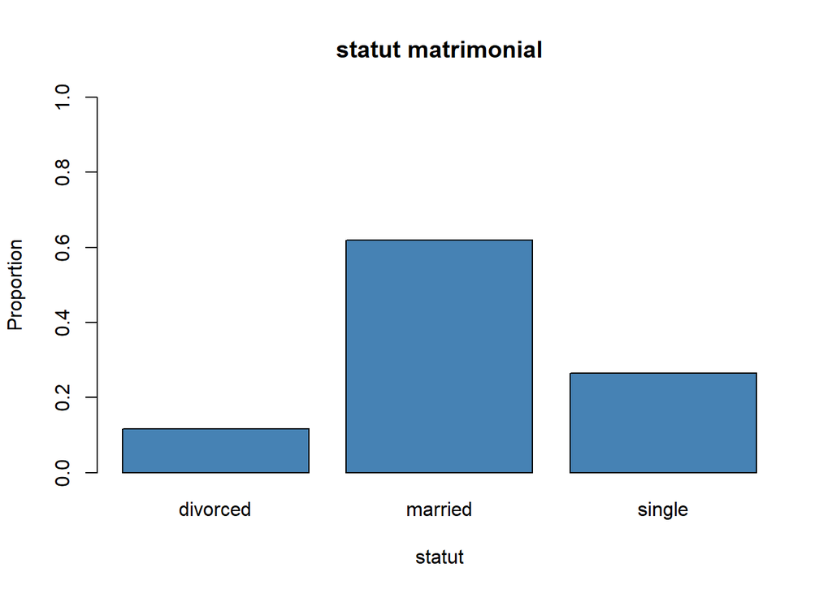

```r
barplot(prop.table(count.marital),ylim = c(0,1),col="steelblue",main="statut matrimonial",ylab="Proportion", xlab="statut")
```

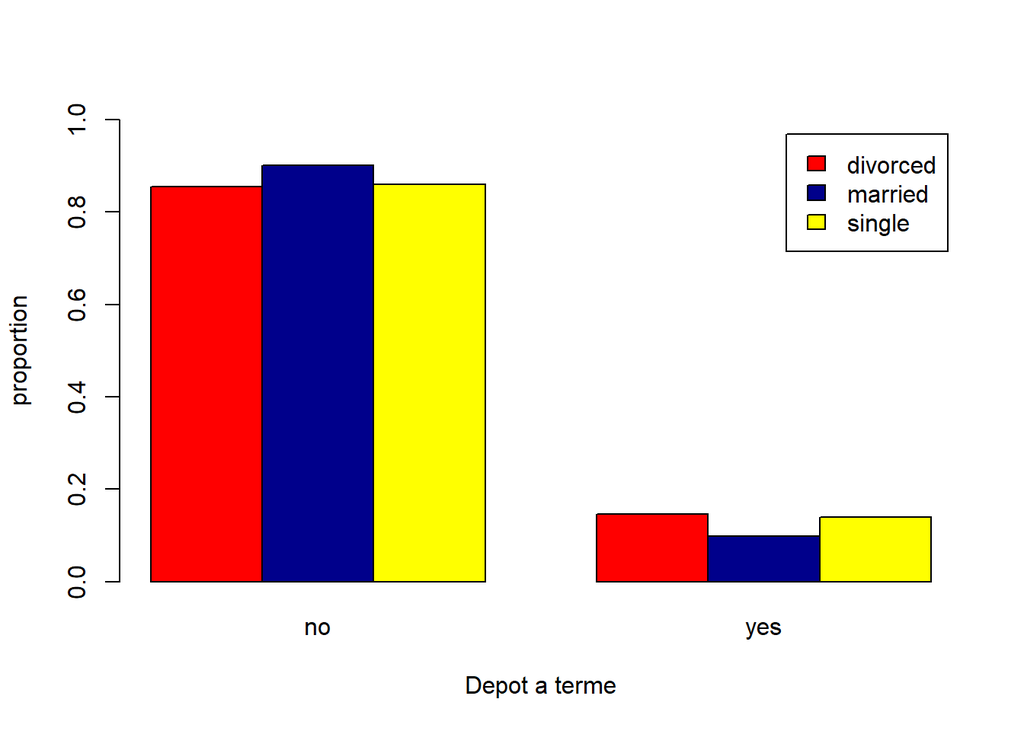

```r
agg <- prop.table(table(data$marital, data$y),1)
barplot(agg,
        xlab = "Depot a terme", ylab = "proportion",
        col = c("red", "darkblue","yellow"),
        legend.text = rownames(agg),
        beside = TRUE,
        ylim=c(0,1)) # Grouped bars
```

```r
chisq.test(table(data$marital, data$y),correct = T)
```

```
##
##  Pearson's Chi-squared test
##
## data:  table(data$marital, data$y)
## X-squared = 19.03, df = 2, p-value = 7.374e-05
```

remarque:

Les clients marriés souscrivent moins un depot a terme.Ceci pourrait etre lie au fait qu’ils ont de grandes charges.

Le test d’independance du khi deux au seuil 5% (p-valeur=0.0) est en faveur d’une association entre le statut matrimonial d’un client et le fait qu’il souscrira ou pas a un depot a terme.

### La propotion de client disposant d’une maison?

```r
house=table(data$housing)
prop.table(house)
```

```
##
##        no       yes
## 0.4339748 0.5660252
```

```r
prop.table(table(data$housing,data$y),1)
```

```
##
##               no        yes
##   no  0.84658512 0.15341488
##   yes 0.91402892 0.08597108
```

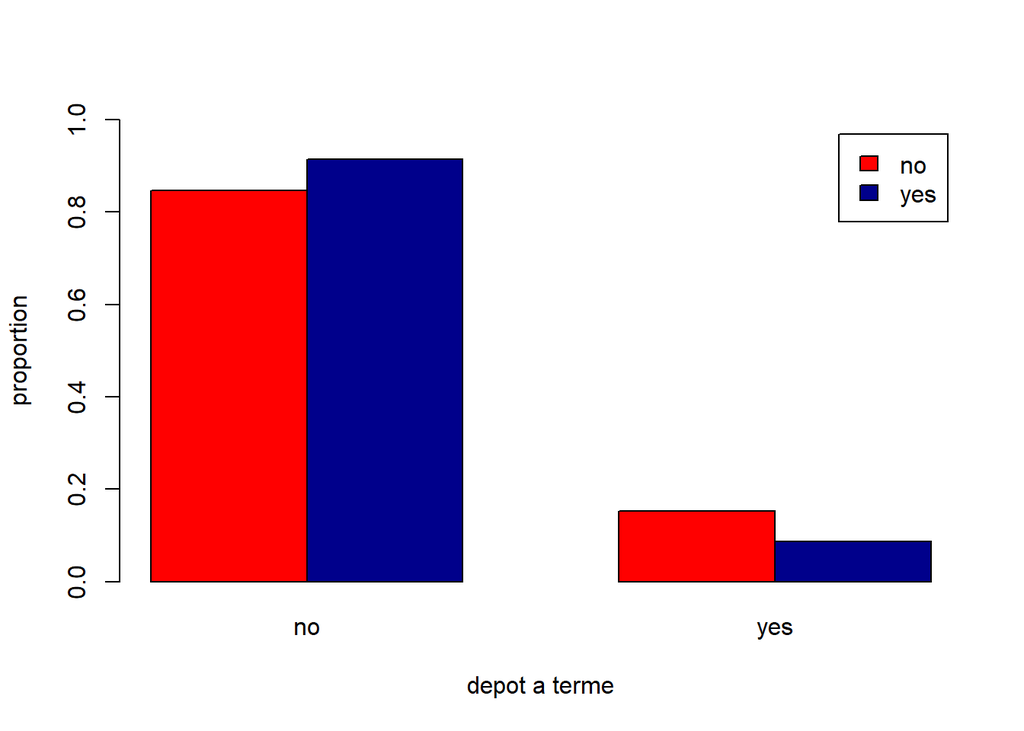

```r
agg <- prop.table(table(data$housing, data$y),1)
barplot(agg,
        xlab = "depot a terme", ylab = "proportion",
        col = c("red", "darkblue"),
        legend.text = rownames(agg),
        beside = TRUE,
        ylim=c(0,1)) # Grouped bars
```

```r
chisq.test(table(data$housing, data$y),correct = T)
```

```
##
##  Pearson's Chi-squared test with Yates' continuity correction
##
## data:  table(data$housing, data$y)
## X-squared = 48.885, df = 1, p-value = 2.715e-12
```

On constate que les clients qui ne diposent pas de maison epargnent plus que ceux qui en diposent.ceci pourrait etre lie au fait que ceux-ci epargnent pour pouvoir se contruire une maison dans l’avenir.

Le test d’independance du khi deux au seuil 5% (p-valeur=0.0) est en faveur d’une association entre le fait qu’un client dispose d’une maison et le fait qu’il souscrira ou pas a un depot a terme.

### Quel est le niveau d’etude dominant des clients?

```r
etude=table(data$education)
prop.table(etude)
```

```
##
##    primary  secondary   tertiary    unknown
## 0.14996682 0.51006415 0.29860650 0.04136253
```

```r
prop.table(table(data$education,data$y),1)
```

```
##
##                     no        yes
##   primary   0.90560472 0.09439528
##   secondary 0.89375542 0.10624458
##   tertiary  0.85703704 0.14296296
##   unknown   0.89839572 0.10160428
```

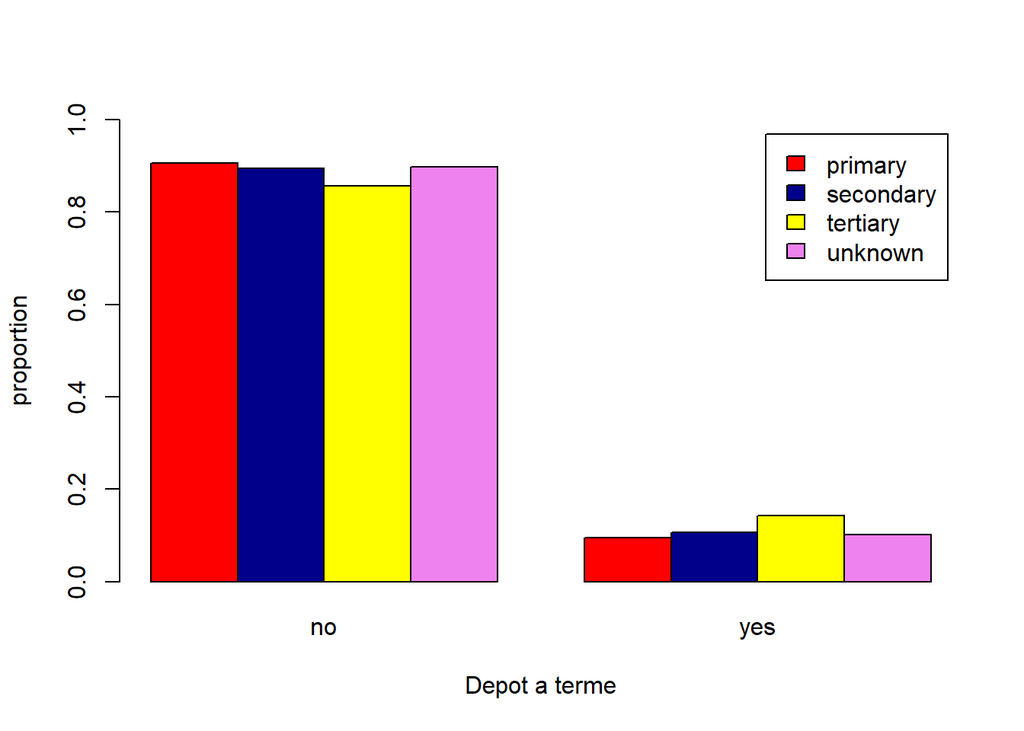

```r
agg <- prop.table(table(data$education, data$y),1)
barplot(agg,
        xlab = "Depot a terme", ylab = "proportion",
        col = c("red", "darkblue","yellow","violet"),
        legend.text = rownames(agg),
        beside = TRUE,
        ylim=c(0,1)) # Grouped bars
```

```r
chisq.test(table(data$education,data$y),1)
```

```
##
##  Pearson's Chi-squared test
##
## data:  table(data$education, data$y)
## X-squared = 15.237, df = 3, p-value = 0.001625
```

On constate que les clients ayant un niveau d’etude tertiaire souscrivent plus un depot a terme que les clients ayant un niveau d’etude inferieur.

### Repartition du type d’emploi des clients

```r
job=table(data$job)
prop.table(job)
```

```
##
##        admin.   blue-collar  entrepreneur     housemaid    management
##    0.10572882    0.20924574    0.03715992    0.02477328    0.21433311
##       retired self-employed      services       student    technician
##    0.05087370    0.04047777    0.09223623    0.01857996    0.16987392
##    unemployed       unknown
##    0.02831232    0.00840522
```

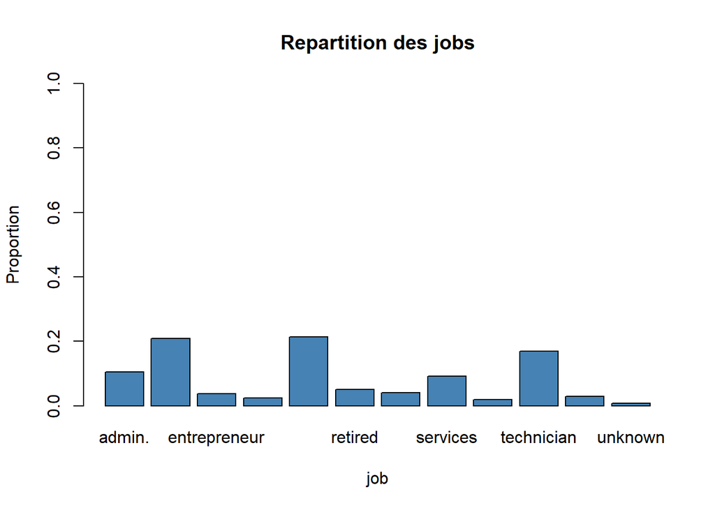

```r
barplot(prop.table(job),ylim = c(0,1),col="steelblue",main="Repartition des jobs",ylab="Proportion", xlab="job")
```

[figure not shown]

```r
agg <- prop.table(table(data$job, data$y),1)
barplot(agg,
        xlab = "depot a terme", ylab = "proportion",
        col = c("darkblue"),
        legend.text = rownames(agg),
        beside = TRUE,
        ylim=c(0,1)) # Grouped bars
```

```r
prop.table(table(data$job,data$y),1)
```

```
##
##                         no        yes
##   admin.        0.87866109 0.12133891
##   blue-collar   0.92706131 0.07293869
##   entrepreneur  0.91071429 0.08928571
##   housemaid     0.87500000 0.12500000
##   management    0.86480908 0.13519092
##   retired       0.76521739 0.23478261
##   self-employed 0.89071038 0.10928962
##   services      0.90887290 0.09112710
##   student       0.77380952 0.22619048
##   technician    0.89192708 0.10807292
##   unemployed    0.89843750 0.10156250
##   unknown       0.81578947 0.18421053
```

On constate que les etudiants et les retraites souscrivent plus un depot a terme.

```r
chisq.test(table(data$job,data$y),1)
```

```
##
##  Pearson's Chi-squared test
##
## data:  table(data$job, data$y)
## X-squared = 68.988, df = 11, p-value = 1.901e-10
```

### Proportion de clients ayant effectue un pret

```r
loan=table(data$loan)
prop.table(loan)
```

```
##
##        no       yes
## 0.8471577 0.1528423
```

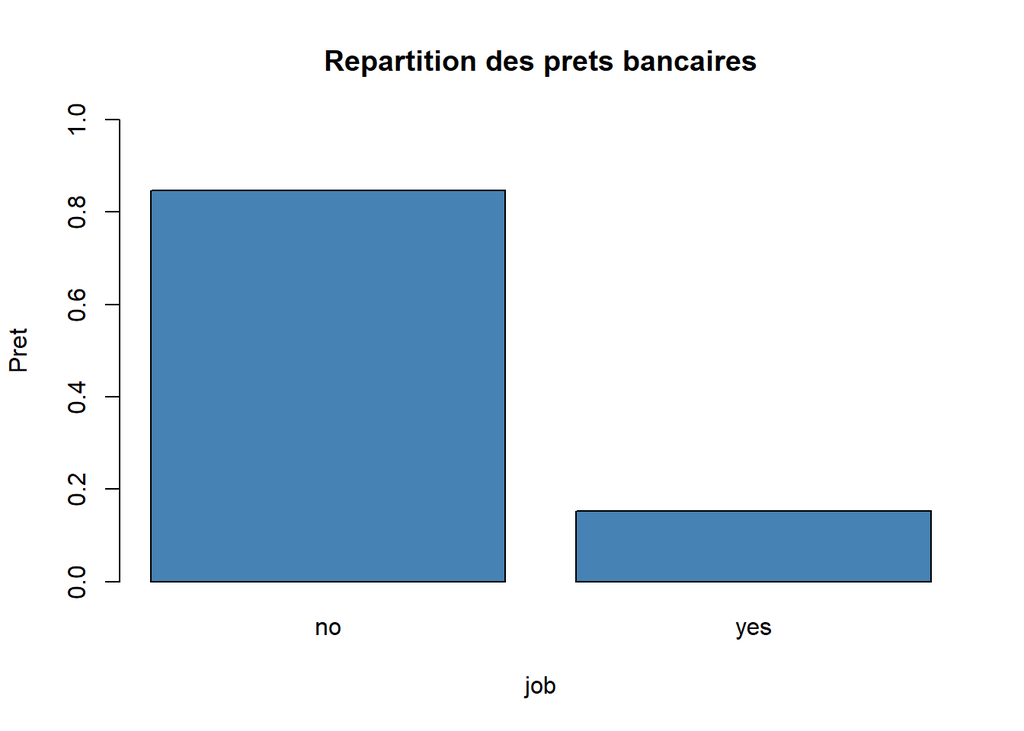

```r
barplot(prop.table(loan),ylim = c(0,1),col="steelblue",main="Repartition des prets bancaires",ylab="Pret", xlab="job")
```

```r
prop.table(table(data$loan,data$y),1)
```

```
##
##               no        yes
##   no  0.87519582 0.12480418
##   yes 0.93777135 0.06222865
```

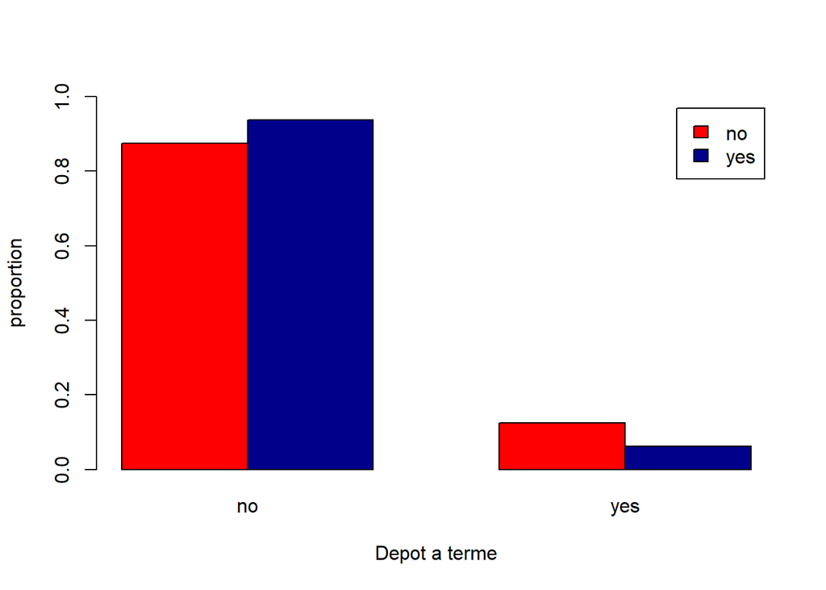

```r
agg <- prop.table(table(data$loan, data$y),1)
barplot(agg,
        xlab = "Depot a terme", ylab = "proportion",
        col = c("red","darkblue"),
        legend.text = rownames(agg),
        beside = TRUE,
        ylim=c(0,1)) # Grouped bars
```

```r
chisq.test(table(data$loan,data$y),1)
```

```
##
##  Pearson's Chi-squared test with Yates' continuity correction
##
## data:  table(data$loan, data$y)
## X-squared = 21.872, df = 1, p-value = 2.915e-06
```

remarque:

les clients qui n’ont pas effectue de pret souscrivent plus que ceux qui en ont fait

Le test d’independance du khi deux au seuil 5% (p-valeur=0.0) est en faveur d’une association entre les deux variables

### Le depot a terme concerne plus quel tranche d’age?

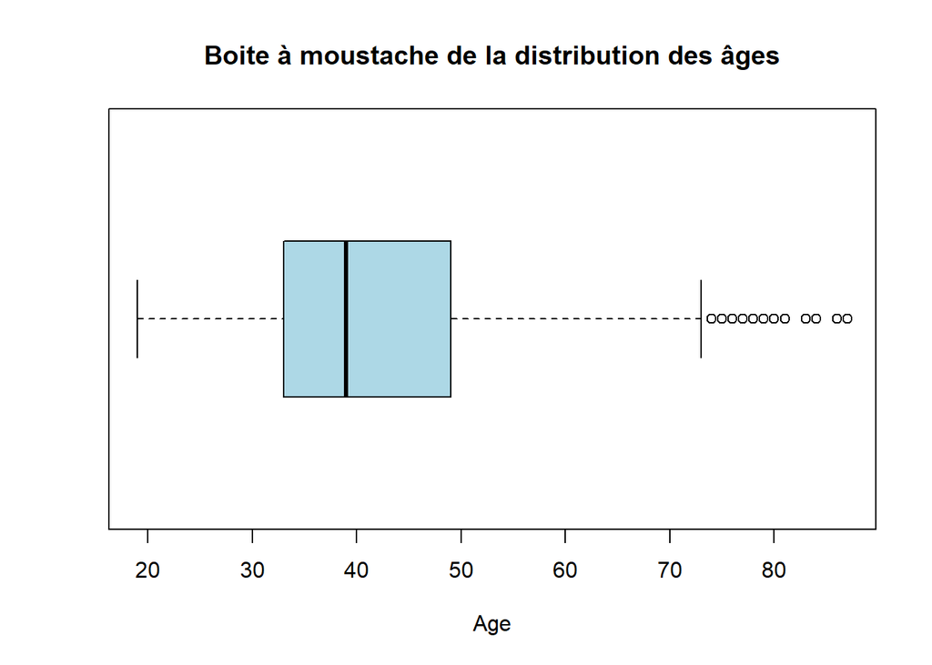

```r
boxplot(data$age,
        col="lightblue",
        horizontal = T,
        main="Boite à moustache de la distribution des âges",
        xlab="Age"
        )
```

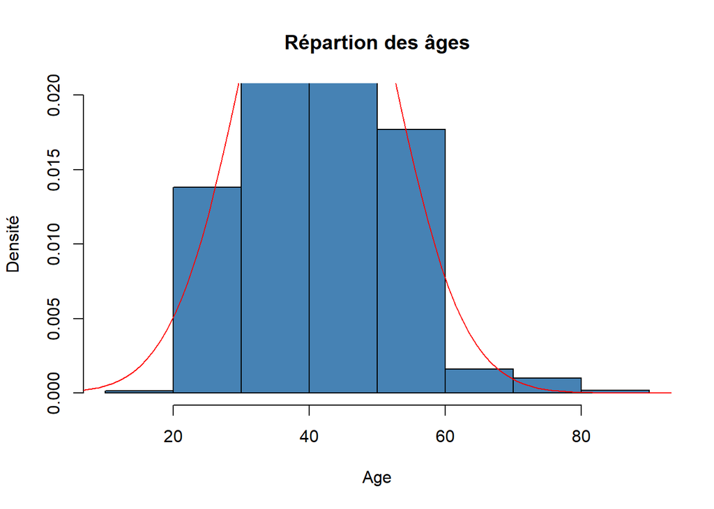

```r
hist(data$age,
     breaks = 5,
     col="steelblue",
     main="Répartion des âges",
     xlab="Age",
     ylab="Densité",
     freq=F,
     ylim=c(0,0.02))
x <- seq(0, 120, length.out=120)
y <- with(data, dnorm(x, mean(age), sd(age)))
lines(x, y, col = "red")
```

## Conclusion

Nous constatons que la banque ne mene pas une tres forte campagne car La majorite des client sont contactes moins de 4 fois(75%) durant la campagne et rare sont les clients qui sont contactes au-dela de 5 fois pendant la campagne.

On constate que les clients retraitees et etudiants souscrivent plus a un depot a terme.

On fait le constat que le niveau scolaire dominant des clients est le secondaire.Et ceux qui souscrivent le plus on un niveau tertiaire

On constate que les clients qui ne diposent pas de maison epargnent plus que ceux qui en diposent.

On enregistre un taux eleve de client n’ayant pas effectue de pret.

on constate que les clients n’ayant pas souscrit l’annee precedente on de forte chance de ne pas souscrire l’annee suivante.Par contre les clients ayant souscrit l’annee derniere ont de fortes chances de le refaire l’annee suivante

.les variables housing,job,loan,poutcomes,education,marital sont associes a la variable Y. ce sont des potentiels facteurs qui pouraient predire si un client souscrira un depot a terme ou pas